# Case 2 Lab

### Executive Summary

This tutorial illustrates the implentations of clustering and association rule mining in ®, which will help you finish Case Study 2.

## Content

### [Data](https://blackboard.uc.edu/bbcswebdav/pid-8185668-dt-content-rid-34101010_2/courses/13SS_BANA4080001/Lab5_Clustering%20Association%20Rule%282%29.html#data)

### [RODBC](https://blackboard.uc.edu/bbcswebdav/pid-8185668-dt-content-rid-34101010_2/courses/13SS_BANA4080001/Lab5_Clustering%20Association%20Rule%282%29.html#rodbc)

### [Clustering](https://blackboard.uc.edu/bbcswebdav/pid-8185668-dt-content-rid-34101010_2/courses/13SS_BANA4080001/Lab5_Clustering%20Association%20Rule%282%29.html#cluster)

### [Association Rules](https://blackboard.uc.edu/bbcswebdav/pid-8185668-dt-content-rid-34101010_2/courses/13SS_BANA4080001/Lab5_Clustering%20Association%20Rule%282%29.html#arules)

### Cincinnati Zoo Data

This lab uses the Cincinnati Zoo Data, which is from former MSQA student Ben Cofie's Master's thesis. A copy of his thesis can be found on BB.

### RODBC package

The [RODBC](http://cran.r-project.org/web/packages/RODBC/RODBC.pdf) package provides access to databases (including Microsoft Access and Microsoft SQL Server) through an ODBC interface. The primary functions are given below.

| Function | Description |
| --- | --- |
| odbcConnect(dsn, uid=“”, pwd=“”) | Open a connection to an ODBC database |
| sqlFetch(channel, sqtable) | Read a table from an ODBC database into a data frame |
| sqlQuery(channel, query) | Submit a query to an ODBC database and return the results |
| sqlSave(channel, mydf, tablename = sqtable, append = FALSE) | Write or update (append=True) a data frame to a table in the ODBC database |
| sqlDrop(channel, sqtable) | Remove a table from the ODBC database |
| close(channel) | Close the connection |

### Clustering

Data I/O and Some Preprocessing

```r
# Import raw data from excel
library(RODBC)
channel <- odbcConnectExcel("I:/BANA7047/Case 2/qry_Food_by_Month.xls")
ZooFood <- sqlFetch(channel, "qry_Food_by_MonthEdited")
odbcClose(channel)
```

**Note:** *odbcConnectExcel* function is only usable with 32-bit Windows. To change setting in Rstudio, go to Tools -> Options -> General R Versions: select 32 bit R version. You may need to restart Rstudio to make the change take effect.

```r
load("I:/BANA7047/Case 2/case2 RWSpace.RData")
```

```r
# Delete missing rows with missing data
ZooFood <- na.omit(ZooFood)
# Exclude column 1 which contains text from data matrix
ZooFood.use <- ZooFood[, -1]
# re-name the rows
dimnames(ZooFood.use)[[1]] <- ZooFood[, 1]
# Scale data using the column means.
ZooFood.use <- scale(ZooFood.use)  #Scale Data to have zero mean and unit variance for each column
```

Determine number of clusters. Here a simple within group sum of squares method is used. For more sophiscated methods, see for example [blog](http://blog.echen.me/2011/03/19/counting-clusters/), or [course notes](http://www.bx.psu.edu/old/courses/bx-fall04/How_Many_Clusters.pdf).

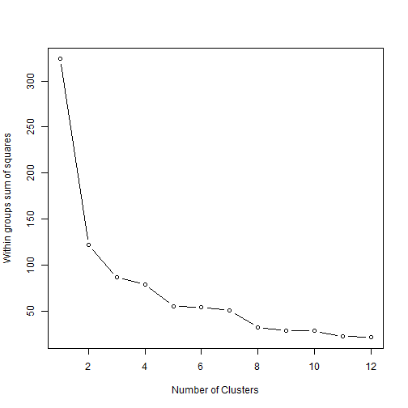

```r
# Determine number of clusters
wss <- (nrow(ZooFood.use) - 1) * sum(apply(ZooFood.use, 2, var))
for (i in 2:12) wss[i] <- sum(kmeans(ZooFood.use, centers = i)$withinss)
plot(1:12, wss, type = "b", xlab = "Number of Clusters", ylab = "Within groups sum of squares")
```

Use k-means method for clustering and plot results.

```r
# K-Means Cluster Analysis
fit <- kmeans(ZooFood.use, 5)  #5 cluster solution
# Display number of clusters in each cluster
table(fit$cluster)
```

```
##
##  1  2  3  4  5
##  6  2  9 29  9
```

```r
# Plot cluster in kmeans
install.packages("fpc")
```

```
## Error: trying to use CRAN without setting a mirror
```

```r
library(fpc)
```

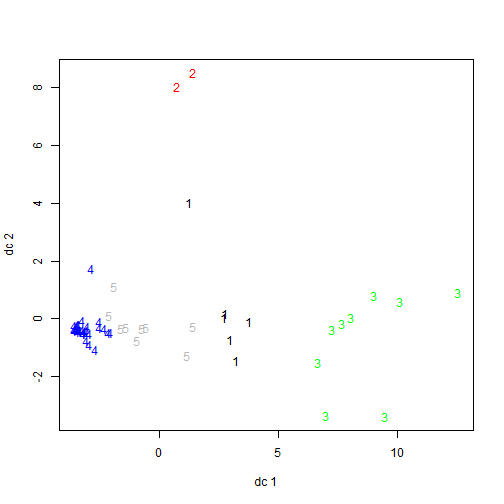

```r
plotcluster(ZooFood.use, fit$cluster)
```

```r
# See exactly which item are in 1st group
ZooFood$NickName[fit$cluster == 1]
```

```
## [1] Cheeseburger Basket   Chicken Tender Basket Gatorade
## [4] Hot Dog Basket        IceCreamCone          Soft Pretzel
## 55 Levels: Alchohol Bottled Water Burger Capri Sun ... Whole/Slice Pepp
```

```r
# get cluster means for scaled data
aggregate(ZooFood.use, by = list(fit$cluster), FUN = mean)
```

```
##   Group.1 Oct, 10 Nov, 10 Dec, 10  Jan, 11  Feb, 11 Mar, 11
## 1       1  0.9063  0.9100  0.3625  0.32337  0.23008  0.9476
## 2       2 -0.7711  0.6925  3.1198  1.96475 -0.34338 -0.6233
## 3       3  1.5925  1.7757  1.2521  1.49539  2.00477  1.7317
## 4       4 -0.5123 -0.7171 -0.6124 -0.64786 -0.63518 -0.6302
## 5       5 -0.3744 -0.2255 -0.2139 -0.06003 -0.03514 -0.1943
```

```r
# or alternatively, use the output of kmeans
fit$centers
```

```
##   Oct, 10 Nov, 10 Dec, 10  Jan, 11  Feb, 11 Mar, 11
## 1  0.9063  0.9100  0.3625  0.32337  0.23008  0.9476
## 2 -0.7711  0.6925  3.1198  1.96475 -0.34338 -0.6233
## 3  1.5925  1.7757  1.2521  1.49539  2.00477  1.7317
## 4 -0.5123 -0.7171 -0.6124 -0.64786 -0.63518 -0.6302
## 5 -0.3744 -0.2255 -0.2139 -0.06003 -0.03514 -0.1943
```

```r
# get cluster means for raw data
Ageish <- aggregate(ZooFood[, -c(1, 1)], by = list(fit$cluster), FUN = mean)
Ageish
```

```
##   Group.1 Oct, 10 Nov, 10 Dec, 10 Jan, 11 Feb, 11 Mar, 11
## 1       1   796.5  296.33  285.83  42.167  72.667  343.00
## 2       2     9.0  260.50 1028.50 109.000  27.500   24.00
## 3       3  1118.7  439.00  525.44  89.889 212.444  502.22
## 4       4   130.5   28.21   23.24   2.621   4.517   22.59
## 5       5   195.2  109.22  130.56  26.556  51.778  111.11
```

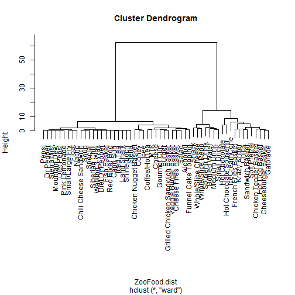

```r
# Wards Method or Hierarchical clustering Calculate the distance matrix
ZooFood.dist = dist(ZooFood.use)
# Obtain clusters using the Wards method
ZooFood.hclust = hclust(ZooFood.dist, method = "ward")
plot(ZooFood.hclust)
```

```r
# Cut dendrogram at the 3 clusters level and obtain cluster membership
groupZooFood.3 = cutree(ZooFood.hclust, k = 3)
table(groupZooFood.3)
```

```
## groupZooFood.3
##  1  2  3
## 36  7 12
```

```r
# See exactly which item are in third group
ZooFood$NickName[groupZooFood.3 == 3]
```

```
##  [1] Cheeseburger Basket    Chicken Tender Basket  Chips
##  [4] French Fries Basket    Gatorade               Hot Chocolate
##  [7] Hot Chocolate Souvenir Hot Dog Basket         IceCreamCone
## [10] Krazy Kritter          Sandwich Basket        Soft Pretzel
## 55 Levels: Alchohol Bottled Water Burger Capri Sun ... Whole/Slice Pepp
```

```r
# get cluster means for raw data
aggregate(ZooFood[, -c(1, 1)], by = list(groupZooFood.3), FUN = mean)
```

```
##   Group.1 Oct, 10 Nov, 10 Dec, 10 Jan, 11 Feb, 11 Mar, 11
## 1       1   135.5   39.67   42.22   6.917   11.22   36.44
## 2       2  1316.7  472.14  597.00  92.714  208.29  518.43
## 3       3   525.9  276.50  387.58  58.083   94.83  278.33
```

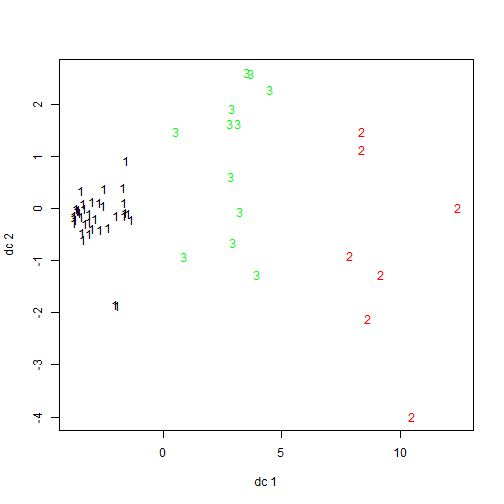

```r
# Centroid Plot against 1st 2 discriminant functions Load the fpc library
# needed for plotcluster function
library(fpc)
# plotcluster(ZooFood, fit$cluster)
plotcluster(ZooFood.use, groupZooFood.3)
```

[go to top](https://blackboard.uc.edu/bbcswebdav/pid-8185668-dt-content-rid-34101010_2/courses/13SS_BANA4080001/Lab5_Clustering%20Association%20Rule%282%29.html#content)

### Association Rules

Association Rules is a popular and well researched method for discovering interesting relations between variables in large databases. [*arules*](http://cran.r-project.org/web/packages/arules/arules.pdf) package in R provides a basic infrastructure for creating and manipulating input data sets and for analyzing the resulting itemsets and rules.

Data I/O and summary of transaction data

```r
# Import raw data from excel
library(RODBC)
channel <- odbcConnectExcel("I:/BANA7047/Case 2/food_4_association.xls")
TransFood <- sqlFetch(channel, "Sheet1")
odbcClose(channel)
```

```r
load("I:/BANA7047/Case 2/case2 RWSpace.RData")

TransFood.use <- TransFood[, -c(1, 1)]

# Load the arules library
library(arules)
# Transform raw data into matrix form
TransFood.use <- as(as.matrix(TransFood.use), "transactions")
# TransFood.use <- as.matrix(TransFood.use)

# run summary report
summary(TransFood.use)
```

```
## transactions as itemMatrix in sparse format with
##  19076 rows (elements/itemsets/transactions) and
##  118 columns (items) and a density of 0.02231
##
## most frequent items:
##   Bottled WaterFood Slice of CheeseFood    Medium DrinkFood
##                3166                3072                2871
##     Small DrinkFood   Slice of PeppFood             (Other)
##                2769                2354               35981
##
## element (itemset/transaction) length distribution:
## sizes
##    0    1    2    3    4    5    6    7    8    9   10   11   12   13   15
##  197 5675 5178 3253 2129 1293  655  351  178   95   42   14    8    7    1
##
##    Min. 1st Qu.  Median    Mean 3rd Qu.    Max.
##    0.00    1.00    2.00    2.63    4.00   15.00
##
## includes extended item information - examples:
##              labels
## 1    Add CheeseFood
## 2          BeerFood
## 3 Bottled WaterFood
##
## includes extended transaction information - examples:
##   transactionID
## 1             1
## 2             2
## 3             3
```

*as()* function coerce the dataset into transaction data type for association rules mining. *summary()* displays the most frequent items in the data set, information about the transaction length distribution and that the data set contains some extended transaction information. We see that the data set contains transaction IDs. This additional information can be used for analyzing the data set.

To find the very long transactions we can use the *size()* and select very long transactions (containing more than 10 items).

```r
#
transactionInfo(TransFood.use[size(TransFood.use) > 10])
```

```
##       transactionID
## 153             153
## 1665           1665
## 1699           1699
## 2252           2252
## 4420           4420
## 4723           4723
## 4734           4734
## 5374           5374
## 6215           6215
## 6764           6764
## 7589           7589
## 9758           9758
## 9910           9910
## 10112         10112
```

[output cut: 16 more lines]

To see which items are important in the data set we can use the *itemFrequencyPlot()*. To reduce the number of items, we only plot the item frequency for items with a support greater than 10%. The label size is reduced with the parameter *cex.names*.

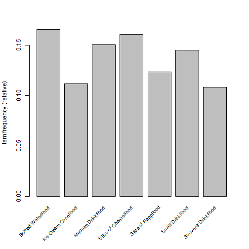

```r
#
itemFrequencyPlot(TransFood.use, support = 0.1, cex.names = 0.8)
```

```r
# Run the apriori algorithm
basket_rules <- apriori(TransFood.use, parameter = list(sup = 0.003, conf = 0.7,
    target = "rules"))
```

```
##
## parameter specification:
##  confidence minval smax arem  aval originalSupport support minlen maxlen
##         0.7    0.1    1 none FALSE            TRUE   0.003      1     10
##  target   ext
##   rules FALSE
##
## algorithmic control:
##  filter tree heap memopt load sort verbose
##     0.1 TRUE TRUE  FALSE TRUE    2    TRUE
##
## apriori - find association rules with the apriori algorithm
## version 4.21 (2004.05.09)        (c) 1996-2004   Christian Borgelt
## set item appearances ...[0 item(s)] done [0.00s].
## set transactions ...[115 item(s), 19076 transaction(s)] done [0.00s].
## sorting and recoding items ... [74 item(s)] done [0.00s].
## creating transaction tree ... done [0.01s].
## checking subsets of size 1 2 3 4 done [0.00s].
## writing ... [23 rule(s)] done [0.00s].
## creating S4 object  ... done [0.00s].
```

```r
summary(basket_rules)
```

```
## set of 23 rules
##
## rule length distribution (lhs + rhs):sizes
##  2  3
##  5 18
##
##    Min. 1st Qu.  Median    Mean 3rd Qu.    Max.
##    2.00    3.00    3.00    2.78    3.00    3.00
##
## summary of quality measures:
##     support          confidence         lift
##  Min.   :0.00309   Min.   :0.709   Min.   : 6.36
##  1st Qu.:0.00377   1st Qu.:0.798   1st Qu.: 8.23
##  Median :0.00435   Median :0.870   Median : 8.91
##  Mean   :0.00664   Mean   :0.862   Mean   : 9.76
##  3rd Qu.:0.00556   3rd Qu.:0.922   3rd Qu.: 9.19
##  Max.   :0.02857   Max.   :1.000   Max.   :21.83
##
## mining info:
##           data ntransactions support confidence
##  TransFood.use         19076   0.003        0.7
```

Recall from class:

- **Support**: The support of an itemset X or $supp(X)$ is defined as the proportion of transactions in the data set which contain the itemset. In the zoo data, the support for the rules is relatively low, with a maximum support of no more than 3%.
- **Confidence**: The confidence of a rule is defined as $conf( X\Rightarrow Y) = supp( X \cup Y )/supp(X)$. For example, the rule {milk, bread} $\Rightarrow$ {butter} has a confidence of 0.5, which means that for 50% of the transactions containing milk and bread the rule is correct. Confidence can be interpreted as an estimate of the conditional probability P(Y |X), the probability of finding the RHS of the rule in transactions under the condition that these transactions also contain the LHS. Association rules are required to satisfy both a minimum support and a minimum confidence constraint at the same time.
- **Lift**: Life is a popular measure of to filter or rank found rules. The lift of a rule is defined as $lift(X \Rightarrow Y ) = supp(X \cup Y )/(supp(X)supp(Y ))$. Lift can be interpreted as the deviation of the support of the whole rule from the support expected under independence given the supports of the LHS and the RHS. Greater lift values indicate stronger associations.

```r
# Check the generated rules using inspect
inspect(basket_rules)
```

```
##    lhs                      rhs                        support confidence   lift
## 1  {FloatFood}           => {Ice Cream ConeFood}      0.007025     0.7090  6.356
## 2  {Side of CheeseFood}  => {Hot DogFood}             0.006291     0.9231 21.606
## 3  {ToppingFood}         => {Ice Cream ConeFood}      0.028570     0.9982  8.948
## 4  {Chicken TendersFood} => {French Fries BasketFood} 0.017299     0.7586  7.772
## 5  {CheeseburgerFood}    => {French Fries BasketFood} 0.016880     0.7931  8.125
## 6  {Cheese ConeyFood,
##     Side of CheeseFood}  => {Hot DogFood}             0.004351     0.9326 21.828
## 7  {Bottled WaterFood,
##     ToppingFood}         => {Ice Cream ConeFood}      0.004036     1.0000  8.964
## 8  {Add CheeseFood,
##     Bottled WaterFood}   => {Soft Pretzel $3_39Food}  0.003827     0.8022  8.754
## 9  {CheeseburgerFood,
##     Chicken TendersFood} => {French Fries BasketFood} 0.003932     0.9615  9.851
## 10 {Chicken TendersFood,
##     Souvenir DrinkFood}  => {French Fries BasketFood} 0.003198     0.7922  8.116
## 11 {Chicken TendersFood,
##     Krazy KritterFood}   => {French Fries BasketFood} 0.005662     0.9558  9.792
## 12 {Chicken TendersFood,
##     Slice of PeppFood}   => {French Fries BasketFood} 0.003670     0.9211  9.436
## 13 {Chicken TendersFood,
##     Small DrinkFood}     => {French Fries BasketFood} 0.004823     0.8214  8.415
## 14 {Chicken TendersFood,
##     Medium DrinkFood}    => {French Fries BasketFood} 0.004141     0.8144  8.344
## 15 {Bottled WaterFood,
##     Chicken TendersFood} => {French Fries BasketFood} 0.003460     0.7586  7.772
## 16 {Chicken TendersFood,
##     Slice of CheeseFood} => {French Fries BasketFood} 0.005399     0.8729  8.943
## 17 {CheeseburgerFood,
##     Souvenir DrinkFood}  => {French Fries BasketFood} 0.003250     0.9118  9.341
## 18 {CheeseburgerFood,
##     Krazy KritterFood}   => {French Fries BasketFood} 0.005452     0.8814  9.029
## 19 {CheeseburgerFood,
##     Slice of PeppFood}   => {French Fries BasketFood} 0.003722     0.8659  8.871
## 20 {CheeseburgerFood,
##     Small DrinkFood}     => {French Fries BasketFood} 0.004141     0.8316  8.519
## 21 {CheeseburgerFood,
##     Medium DrinkFood}    => {French Fries BasketFood} 0.005190     0.8761  8.976
## 22 {Bottled WaterFood,
##     CheeseburgerFood}    => {French Fries BasketFood} 0.003093     0.7662  7.850
## 23 {CheeseburgerFood,
##     Slice of CheeseFood} => {French Fries BasketFood} 0.005242     0.8696  8.909
```

```r
# Basket rules of size greater than 2
inspect(subset(basket_rules, size(basket_rules) > 2))
```

```
##    lhs                      rhs                        support confidence   lift
## 1  {Cheese ConeyFood,
##     Side of CheeseFood}  => {Hot DogFood}             0.004351     0.9326 21.828
## 2  {Bottled WaterFood,
##     ToppingFood}         => {Ice Cream ConeFood}      0.004036     1.0000  8.964
## 3  {Add CheeseFood,
##     Bottled WaterFood}   => {Soft Pretzel $3_39Food}  0.003827     0.8022  8.754
## 4  {CheeseburgerFood,
##     Chicken TendersFood} => {French Fries BasketFood} 0.003932     0.9615  9.851
## 5  {Chicken TendersFood,
##     Souvenir DrinkFood}  => {French Fries BasketFood} 0.003198     0.7922  8.116
## 6  {Chicken TendersFood,
##     Krazy KritterFood}   => {French Fries BasketFood} 0.005662     0.9558  9.792
## 7  {Chicken TendersFood,
##     Slice of PeppFood}   => {French Fries BasketFood} 0.003670     0.9211  9.436
## 8  {Chicken TendersFood,
##     Small DrinkFood}     => {French Fries BasketFood} 0.004823     0.8214  8.415
## 9  {Chicken TendersFood,
##     Medium DrinkFood}    => {French Fries BasketFood} 0.004141     0.8144  8.344
## 10 {Bottled WaterFood,
##     Chicken TendersFood} => {French Fries BasketFood} 0.003460     0.7586  7.772
## 11 {Chicken TendersFood,
##     Slice of CheeseFood} => {French Fries BasketFood} 0.005399     0.8729  8.943
## 12 {CheeseburgerFood,
##     Souvenir DrinkFood}  => {French Fries BasketFood} 0.003250     0.9118  9.341
## 13 {CheeseburgerFood,
##     Krazy KritterFood}   => {French Fries BasketFood} 0.005452     0.8814  9.029
## 14 {CheeseburgerFood,
##     Slice of PeppFood}   => {French Fries BasketFood} 0.003722     0.8659  8.871
## 15 {CheeseburgerFood,
##     Small DrinkFood}     => {French Fries BasketFood} 0.004141     0.8316  8.519
## 16 {CheeseburgerFood,
##     Medium DrinkFood}    => {French Fries BasketFood} 0.005190     0.8761  8.976
## 17 {Bottled WaterFood,
##     CheeseburgerFood}    => {French Fries BasketFood} 0.003093     0.7662  7.850
## 18 {CheeseburgerFood,
##     Slice of CheeseFood} => {French Fries BasketFood} 0.005242     0.8696  8.909
```

```r
# Basket rules of size greater than 3
inspect(subset(basket_rules, size(basket_rules) > 3))
```

There are no rules that have more than 3 items in total (lhs+rhs).

Now find the subset rules that has “Ice Cream ConeFood” in the right hand side. Here we require *lift* measure exceeds 1.2.

```r
icecream.rhs <- subset(basket_rules, subset = rhs %in% "Ice Cream ConeFood" &
    lift > 1.2)
```

Now inspect the subset rules

```r
inspect(icecream.rhs)
```

```
##   lhs                    rhs                   support confidence  lift
## 1 {FloatFood}         => {Ice Cream ConeFood} 0.007025     0.7090 6.356
## 2 {ToppingFood}       => {Ice Cream ConeFood} 0.028570     0.9982 8.948
## 3 {Bottled WaterFood,
##    ToppingFood}       => {Ice Cream ConeFood} 0.004036     1.0000 8.964
```

Now find the subset rules that has “Bottled WaterFood” in the left hand side.

```r
water.lhs <- subset(basket_rules, subset = lhs %in% "Bottled WaterFood" & lift >
    1.2)
```

Now inspect the subset rules

```r
inspect(water.lhs)
```

```
##   lhs                      rhs                        support confidence  lift
## 1 {Bottled WaterFood,
##    ToppingFood}         => {Ice Cream ConeFood}      0.004036     1.0000 8.964
## 2 {Add CheeseFood,
##    Bottled WaterFood}   => {Soft Pretzel $3_39Food}  0.003827     0.8022 8.754
## 3 {Bottled WaterFood,
##    Chicken TendersFood} => {French Fries BasketFood} 0.003460     0.7586 7.772
## 4 {Bottled WaterFood,
##    CheeseburgerFood}    => {French Fries BasketFood} 0.003093     0.7662 7.850
```

[go to top](https://blackboard.uc.edu/bbcswebdav/pid-8185668-dt-content-rid-34101010_2/courses/13SS_BANA4080001/Lab5_Clustering%20Association%20Rule%282%29.html#content)